# part02_theory

**Model**

The one-way ANOVA model can be expressed in two equivalent forms:

### Form 1: Treatment Effects Model

$$Y_{ij} = \mu + \tau_i + \varepsilon_{ij}$$

### Form 2: Group Means Model

$$Y_{ij} = \mu_i + \varepsilon_{ij}$$

### Model Components

**Where:** - $Y_{ij}$ = $j$-th observation in the $i$-th group - $\mu$ = Overall mean (grand mean) - $\tau_i$ = Effect of the $i$-th treatment - $\mu_i$ = Mean of the $i$-th group - $\varepsilon_{ij}$ = Random error term

### Key Relationship

The relationship between the two formulations is given by:

$$\mu_i = \mu + \tau_i$$

### Model Parameters

- $k$ = number of groups or treatments
- $\mu_i$ = population mean of group $i$
- $i = 1, 2, \ldots, k$ (group index)
- $j = 1, 2, \ldots, n_i$ (observation index within each group)
- $n_i$ = number of observations in group $i$

### Error Term Specification

The random error term follows a normal distribution:

$$\varepsilon_{ij} \sim N(0, \sigma^2)$$

**Where:** - $\sigma^2$ = common variance across all groups

### Summary One-Way ANOVA Model

Every general linear model involves estimating parameters for a polynomial in order to predict a quantitative response variable with special requirements of normality, homogeneity of variances, and independence of residuals.

The fixed effects general linear model of One-Way ANOVA involves:

- The response variable or dependent variable must be quantitative.
- The predictor variable must be a qualitative independent variable with at least 2 levels. Particularly in ANOVA models, this variable is called a Factor.
- The expected component of the model arises from estimating zero-degree polynomials, one for each factor level. Estimating the means of each factor level involves estimating the intercept term of a zero-degree polynomial.
- The error component must have a normal distribution, zero mean, homogeneous variance, and the residuals must be independent.
- The normality test is performed using the Shapiro-Wilk test.
- Homogeneity is formally tested using Bartlett’s test.
- Independence concerns the errors. Errors are independent if the statistical units are independent. Statistical units are independent if the design is carried out under this concept. Independence is a required characteristic in the design and cannot be tested in any way.

**Hypothesis**

### Statistical Hypotheses

#### Form 1: Treatment Effects ($\tau_i$)

| Hypothesis Type | Mathematical Formulation | Verbal Description |
| --- | --- | --- |
| **Null Hypothesis ($H_0$)** | $H_0: \tau_1 = \tau_2 = \cdots = \tau_k = 0$ | All treatment effects are zero |
| **Alternative Hypothesis ($H_1$)** | $H_1: \exists\; i \in \{1,2,\ldots,k\} \mid \tau_i \neq 0$ | At least one treatment effect is different from zero |

#### Form 2: Group Means ($\mu_i$)

| Hypothesis Type | Mathematical Formulation | Verbal Description |
| --- | --- | --- |
| **Null Hypothesis ($H_0$)** | $H_0: \mu_1 = \mu_2 = \cdots = \mu_k$ | All group means are equal |
| **Alternative Hypothesis ($H_1$)** | $H_1: \exists\; i,j \in \{1,2,\ldots,k\} \mid i \neq j \land \mu_i \neq \mu_j$ | At least one group mean is different |

### Assumption Tests for ANOVA Residuals

#### Normality Test (e.g., Shapiro-Wilk)

| Hypothesis Type | Mathematical Formulation | Verbal Description |
| --- | --- | --- |
| **Null Hypothesis ($H_0$)** | $H_0: \varepsilon_{ij} \sim N(0, \sigma^2)$ | The residuals are normally distributed |
| **Alternative Hypothesis ($H_1$)** | $H_1: \varepsilon_{ij} \not\sim N(0, \sigma^2)$ | The residuals are not normally distributed |

#### Homogeneity of Variances Test (e.g., Bartlett’s Test)

| Hypothesis Type | Mathematical Formulation | Verbal Description |
| --- | --- | --- |
| **Null Hypothesis ($H_0$)** | $H_0: \sigma_1^2 = \sigma_2^2 = \cdots = \sigma_k^2$ | All group variances are equal |
| **Alternative Hypothesis ($H_1$)** | $H_1: \exists\; i,j \in \{1,2,\ldots,k\} \mid i \neq j \land \sigma_i^2 \neq \sigma_j^2$ | At least one group variance is different |

### Decision Rule

The decision to reject or not reject the null hypothesis is based on the p-value and the significance level $\alpha$:

$$\text{If } p < \alpha \Rightarrow \text{Reject } H_0$$

$$\text{If } p \geq \alpha \Rightarrow \text{Fail to reject } H_0$$

**Where:** - $p$ = p-value from the statistical test - $\alpha$ = significance level (typically 0.05) - $k$ = number of groups or treatments - $\sigma_i^2$ = variance of group $i$ - $\exists$ = “there exists” (existential quantifier)

**Decision Plan**

### Decision-Making Process in ANOVA

The ANOVA test is specifically performed to make decisions.  
The decision-making process on this test has a set of sequential steps, in a particular order que podríamos resumir en responder 3 preguntas, solo con posibilidad de respuesta: “Yes” o “No”.

- Question 01: Are all requeriments satisfied???
- Question 02: Anova Ho is rejected???
- Question 03: At least 2 groups on Tukey`s test???

Recalcamos el hecho de que las preguntas son secuenciales y en orden en particular. Cada paso tiene una decisión con dos posibilidades: “Yes” or “No”. Solo se continua al siguiente paso si es la respuesta es “Yes”.  
Si la respuesta es “No” en algunos de los, no debe continuar, sino que usted ya caído en una decisión general.

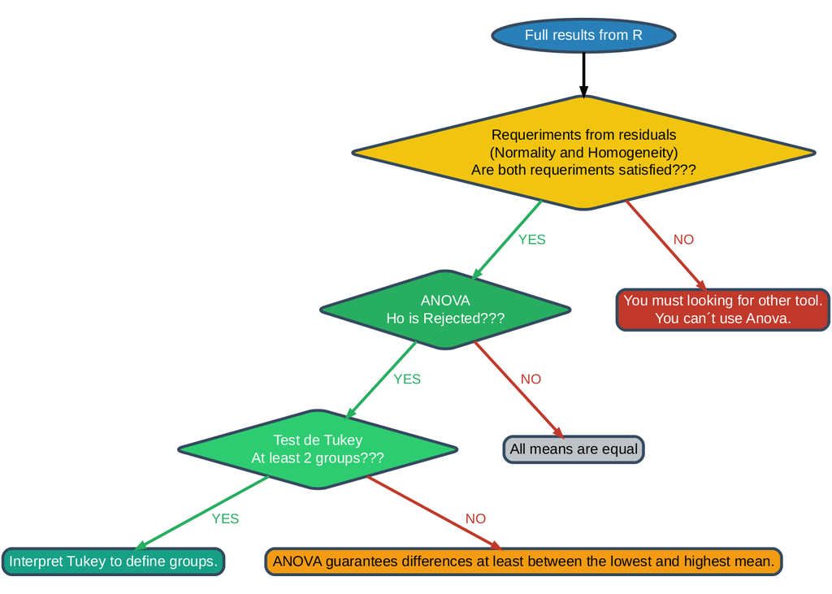

[figure not shown]

Esto nos lleva entonces a 4 escenarios posibles. Cada set de datos cae en un escenario, solo un escenario y nada más que un escenario.

Recalcamos nuevamente que anova a 1 factor posee una estructura secuencial que ordenada y excluye posibilidades, por ellos solo llegamos a 4 escenarios posibles.

Si no hubiera estrucura secuencial y pregutnas excluyentes, tendríamos que tener en cuenta todas las combinaciones posibles de estas 3 preguntas nos enfrentaríamos a 2^3 = 8 posibilidades.

### Generalidades para otros modelos lineales

Esta estructura de escenarios simples, de manera secuencial, ordenada y corta solo ocurrirá en modelos Anova a 1 Factor, y en Anova a 1 Factor con Bloque. Para los modelos de regresión tanto simple, múltiples o en selección de modelos será posible obtener un diagrama de escenarios posibles pero este ya no será tan corto ni tan simple.

En los modelos factoriales (con dos o más factores), en los modelos Ancova y en los modelos Dummy ocurrirá que hay preguntas con las que podríamos ordenar la interpretación pero no podríamos secuenciarlo ya que no son preguntas excluyentes entre si para dar una interpretación de los resultados estadísticos. En esos casos nos veremos obligados a dar un listado de todas las combinaciones posibles.

En vistas de que esto ocurrá, detallamos también los casos posibles.

### Possible Analysis Cases

Any dataset falls into one of these cases, and this implies at least the possibility of providing a general statistical interpretation of what happens to that dataset.

```r
df_decision_cases
```

[output not shown]